This is what we did with Mike and Dave in the stats class: I wil first write a normal script, than put this in a function to later simulate many scripts

```r
library(tidyverse)
library(data.table)
library(mvtnorm) # multivariate normal and t distributions
library(dtplyr) # lets plyr and data.table play nicely
library(plyr)
# library(doParallel)
# library(plyr)
# registerDoParallel(cores=2)
# gen_synth_dataset <- function(n_subjects, n_items, n_repetitions, intecept, effect_size,
#                             subject_ranef_cov, item_ranef_cov){

#   # Make vectors of what things can be
# n_subjects = 10
# n_items = 5
# n_repetitions = 5
# intercept=500
# effect_size = 0
# items <- 1:n_items
# subjects <- 1:n_subjects
# conditions <- 1:2
# reps <- 1:n_repetitions
# intercept = 500
# subject_ranef_cov = 2
# item_ranef_cov = 2
# subject_noise = 0.3
# item_noise = 0.3
# error_noise = 0.3
#   # all possible combinations
# d <- expand.grid(item=items, subject=subjects, cond=conditions, rep=reps) %>% as.data.table()
#
# d[,trial:=1:.N, by="subject"]
# d[,fixef_intercept:=intercept][,fixef_beta:=effect_size]
# d
```

```r
# subj_ranefs <- rmvnorm(n_subjects, mean = rep(0, 2), sigma=diag(subject_ranef_cov) * subject_noise) %>% as.data.table()
# setnames(subj_ranefs, c("subj_intercept", "subj_beta"))
# subj_ranefs[,subject:=as.integer(rownames(subj_ranefs))]
# mean(subj_ranefs$subj_intercept)
#
# #now item random effects
# item_ranefs <- rmvnorm(n_items, mean = rep(0, 2), sigma=diag(item_ranef_cov)* item_noise)  %>% as.data.table()
# setnames(item_ranefs, c("item_intercept", "item_beta"))
# item_ranefs[,item:=as.integer(rownames(item_ranefs))]
# d <- left_join(d, subj_ranefs, by="subject")
# d <- left_join(d, item_ranefs, by="item")
#
# d[,combined_intercept:=fixef_intercept + subj_intercept + item_intercept]
# d[,combined_beta:=fixef_beta + subj_beta + item_beta]
# d[,x:=ifelse(cond==1, -0.5, 0.5)]
# d[,error:=rnorm(nrow(d), sd = error_noise)]
# d[,y:=combined_intercept + combined_beta * x + error]
```

```r
#
# m <- lm(y ~ x, data = d)
# s <- summary(m) %>% coef %>% as.data.table
# s[2,]
```

So this was one dataset d with one linear regression model y = intercept + beta * x + error. However, we set a total of 3 noise parameter to a fix value, and it was only one dataset, giving us one p value. But we want many p values to look at a whole p value distribution!

So lets simulate many datasets. So we put the upper code in two functions. One to generate datasets, one to generate linear regression models. First, we keep the 3 noise values as they are.

To build the first function all we do is copy and past ethe code from above, and add one line on top of the code.

```r
gen_synth_dataset <- function(n_subjects, n_items, n_repetitions, intercept, effect_size,
                              subject_ranef_cov, item_ranef_cov, subject_noise, item_noise, error_noise){
  items <- 1:n_items
  subjects <- 1:n_subjects
  conditions <- 1:2
  reps <- 1:n_repetitions
  d <- expand.grid(item=items, subject=subjects, cond=conditions, rep=reps) %>% as.data.table()
  d[,trial:=1:.N, by="subject"]
  d[,fixef_intercept:=intercept][,fixef_beta:=effect_size]
  #subject random effects
  subj_ranefs <- rmvnorm(n_subjects, mean = rep(0, 2), sigma=diag(subject_ranef_cov) * subject_noise) %>% as.data.table()
  setnames(subj_ranefs, c("subj_intercept", "subj_beta"))
  subj_ranefs[,subject:=as.integer(rownames(subj_ranefs))]
  mean(subj_ranefs$subj_intercept)
  #now item random effects
  item_ranefs <- rmvnorm(n_items, mean = rep(0, 2), sigma=diag(item_ranef_cov)* item_noise)  %>% as.data.table()
  setnames(item_ranefs, c("item_intercept", "item_beta"))
  item_ranefs[,item:=as.integer(rownames(item_ranefs))]
  d <- left_join(d, subj_ranefs, by="subject")
  d <- left_join(d, item_ranefs, by="item")
  #combine everything
  d[,combined_intercept:=fixef_intercept + subj_intercept + item_intercept]
  d[,combined_beta:=fixef_beta + subj_beta + item_beta]
  d[,x:=ifelse(cond==1, -0.5, 0.5)]
  d[,error:=rnorm(nrow(d), sd = error_noise)]
  d[,y:=combined_intercept + combined_beta * x + error]

  return(d)
}
```

This function takes in the data set generation function and a list of parameters. Then it does a simple linear regression and returns the output. (The do.call command the parameter list will be put into the dataset generating function.)

Now we add the parameter list to generate the dataset.

```r
run_fixef_regression <- function(datagen_fun, param_list){
  d <- do.call(datagen_fun, param_list)
  m <- lm(y ~ x, data = d)
  s <- broom::tidy(m)
  return(s[-1,])
}
```

What we do now is simulate the LM of 500 different datasets to receive a p value distribution and the power for a fixed set of noise parameters. We do this 32 times and increase the subject noise by val* 0.15 and the item noise by val 0.03. Then we plot the power of the 32 runs

```r
# power!
library(doParallel)
registerDoParallel(cores=2)
runs = c(0:31)
P5 = matrix(0,32,3)

for (val in runs) {
  param_list <- list(n_subjects = 30, n_items = 5, n_repetitions = 5, intercept=500, effect_size = 0 ,subject_ranef_cov=2, item_ranef_cov=2, subject_noise = 0.0001 + val*0.15, item_noise = 0.00001 + val*0.03, error_noise = 1.0) #Markus: subject_ranef_cov & item_ranef_cov =2 indicates the amount of n_items *2
  nSims <- 500
  fx <- ldply(1:nSims, function(x) run_fixef_regression(gen_synth_dataset, param_list), .parallel=TRUE) %>% as.data.table
  mean(fx$p.value<=0.05) # power
  mean(fx$statistic < -2) # type S error
  mean(fx$estimate) # average beta estimate across sims
  P5[val,1] =  mean(fx$p.value<=0.05)
  P5[val,2] =  mean(fx$statistic < -2)
  P5[val,3] =  mean(fx$estimate)
}
```

Plot power from simulation

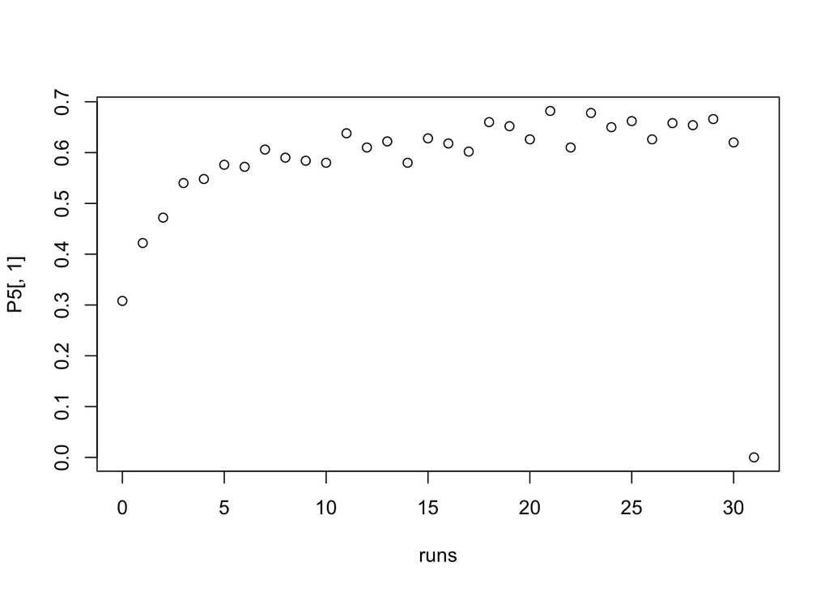

```r
plot(runs, P5[,1])
```

```r
SAVE_P5= P5
```

```r
# # power!
# library(doParallel)
# registerDoParallel(cores=6)
# runs = c(0:31)
# P5 = matrix(0,32,3)
#
# for (val in runs) {
#   param_list <- list(n_subjects = 30, n_items = 50, n_repetitions = 5, intercept=500, effect_size = 0 ,subject_ranef_cov=2, item_ranef_cov=2, subject_noise = 0.0001 + val*0.15, item_noise = 0.00001 + val*0.03, error_noise = 1.0) #Markus: subject_ranef_cov & item_ranef_cov =2 indicates the amount of n_items *2
#   nSims <- 500
#   fx <- ldply(1:nSims, function(x) run_fixef_regression(gen_synth_dataset, param_list), .parallel=TRUE) %>% as.data.table
#   mean(fx$p.value<=0.05) # power
#   mean(fx$statistic < -2) # type S error
#   mean(fx$estimate) # average beta estimate across sims
#   P5[val,1] =  mean(fx$p.value<=0.05)
#   P5[val,2] =  mean(fx$statistic < -2)
#   P5[val,3] =  mean(fx$estimate)
# }
```

```r
#plot(runs, P5[,1])
```

Any thoughts?

```r
# power!
library(doParallel)
registerDoParallel(cores=2)
runs = c(0:10)
P = matrix(0,11,3)

for (val in runs) {
  param_list <- list(n_subjects = 30, n_items = 20, n_repetitions = 10, intercept=500, effect_size = 0 ,subject_ranef_cov=2, item_ranef_cov=2, subject_noise = 0.0001 + val*0.15, item_noise = 0.00001 + val*0.03, error_noise = 1.0) #Markus: subject_ranef_cov & item_ranef_cov =2 indicates the amount of n_items *2
  nSims <- 500
  fx <- ldply(1:nSims, function(x) run_fixef_regression(gen_synth_dataset, param_list), .parallel=TRUE) %>% as.data.table
  mean(fx$p.value<=0.05) # power
  mean(fx$statistic < -2) # type S error
  mean(fx$estimate) # average beta estimate across sims
  P[val,1] =  mean(fx$p.value<=0.05)
  P[val,2] =  mean(fx$statistic < -2)
  P[val,3] =  mean(fx$estimate)
}
```

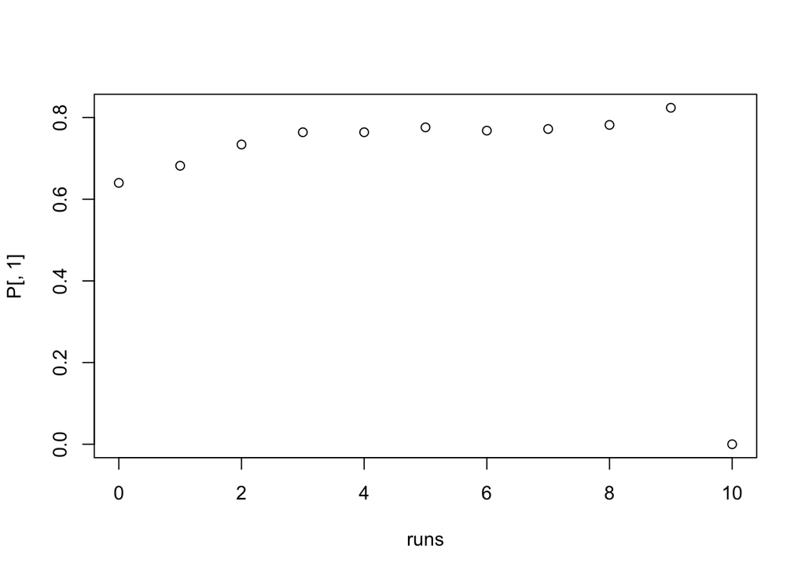

```r
plot(runs, P[,1])
```